Tweede beweging · Verschillen koppelen

# Hoofdstuk 5 — Bestaat het echt?

Betrouwbaarheidsinterval, bootstrap en permutatie

> **Kern-architectuur (besloten 5-7, avond):** eerst interval ↔︎ bootstrap ↔︎ *onze eigen schatting staat in het midden* — daarna, als expliciete wending, toets ↔︎ permutatie ↔︎ *de nul staat in het midden*. Het OZP-scharnier “wat staat er in het midden?” is de wénding zelf, niet de nabeschouwing. De bakker speelt in twee aktes: akte 1 (schatting: welke winkel past bij mijn brood? — marge), akte 2 (toets: stel bakker — hoe gek is een fiets?), met daartussen de omkeer-valkuil (P(brood|bakker) ≠ P(bakker|brood)). Bronnen: bakker-monoloog (oud boek H4 + OZP), object-ontologie (kistje/ton, H3), Pippi (OZP), kraai-diefstal (H4-slot). Getallen: som rechthoekjes +54, r = .578, b = 32.1, t = 2.24, p = .049 (“net aan” — by design). [Waarheidsscript 6-7: permutatie-p = .056 tweezijdig (278 + 278 op 10.000 = 56 per duizend), bootstrap-95% in `_waarheid_getallen_OUTPUT.txt`.]

## 1. Elf

GROF — verhaal-stem, stem-pas volgt. Direct na de diefstal van H4-slot. De dieren demonstreren niets; ze missen gewoon een diamant.

De volgende ochtend waren het er elf.

Niemand zei iets over de kraai. Kraaien zijn kraaien; daar kun je lang over praten, maar het worden er geen twaalf van.

De bever legde de elf opnieuw neer, uit gewoonte, van dof naar fel. De meeuw keek over de rij heen.

“Het is er nog,” zei ze. “De grote glanzen nog steeds meestal meer.”

“Met elf,” zei de bever.

“Met elf,” zei de meeuw.

De olifant keek naar de lege plek in het mos, waar gisteren de gestolen diamant had gelegen.

“En als ze er twee had meegenomen?” vroeg hij. “Of vijf? Of alle twaalf, en er twaalf ándere had neergelegd, uit een ander kistje uit een andere dam?”

De meeuw dacht na.

“Hoeveel kraaien,” zei de olifant langzaam, “verdraagt een patroon?”

Docent-aansluiting: Dat is de vraag van dit hoofdstuk, en het is de eerlijkste vraag die je aan een gevonden patroon kunt stellen. Wij zagen in hoofdstuk 4 een *meestal*: som van de rechthoekjes +54, $r$ = .58, een lijn met een helling van 32. Maar dat zagen we in **één kistje** — twaalf diamantjes die toevallig in één dam bleven hangen. De olifant vraagt, in dieren-woorden, wat een onderzoeker bij elke bevinding hoort te vragen:

> *Is dit patroon van de wereld, of van dit kistje?*

Twee vragen komen daaruit voort, en we stellen ze in deze volgorde — eerst de vraag die gewoon ons eigen spel doorspeelt, dan de vraag waarvoor we de boel moeten omdraaien:

1. **Hoe hard is het?** Onze .58 is een gok, zoals alles in dit boek een gok was — hoe ver zit zo’n gok er gemiddeld naast, met maar twaalf diamantjes? (het interval)
2. **En bestaat het überhaupt?** Kan dit *meestal* óók opduiken in een wereld waar karaat en glans niets met elkaar te maken hebben? (de toets. Voor díé vraag moeten we straks iets geks doen. Doen alsof.)

## 2. Het kistje als ton — hoe hard is die .58?

Begin bij wat we hebben, want dat is de gewoonte van dit boek. In hoofdstuk 1 gokte je een diamantje, en de standaardafwijking vertelde hoe ver je er gemiddeld naast zat. In hoofdstuk 3 gokte je een bordje, en de standaardfout vertelde hetzelfde, een verdieping hoger. Nu is onze beste gok een *verband*: $r$ = .58. Zelfde vraag dus, uit gewoonte: **hoe ver zit zo’n gok er gemiddeld naast?**

Eén kistje gaf .58. Een ander kistje uit dezelfde rivier had .40 kunnen geven. Of .70. Hoe wiebelig is onze schatting?

In hoofdstuk 3 kon je die vraag beantwoorden door de ton te schudden en bordjes te verzamelen. Maar hier wringt iets: **we hébben geen ton.** De rivier geeft ons niet nog honderd kistjes. We hebben twaalf diamantjes en verder niks.

En dan komt de mooiste truc van dit hele boek, en hij is van een schaamteloze eenvoud:

> *Als je geen ton hebt, doe dan alsof je kistje de ton is.*

En we proberen die truc eerst op het vertrouwdste getal dat we hebben — niet de r, maar de **gemiddelde glans**. Die kennen we sinds hoofdstuk 1: 50. Besloten 5-7: opstap op het gemiddelde — de bootstrap wordt geleerd op één volledig bekend getal, en meteen hergebruikt op het spannende.

Leg de twaalf terug in het kistje. Trek er blind één uit, noteer zijn glans — en **leg hem terug**. Trek opnieuw. Twaalf keer. Je hebt nu een nieuw pseudo-kistje: sommige diamantjes zitten er dubbel in, sommige ontbreken (er zijn altijd Kezen die twee keer komen en Anna’s die je misloopt). Reken het gemiddelde van dát kistje uit, schrijf het op een bordje — en hang het aan de muur. En opnieuw, en opnieuw: de eeuwige herhaling, maar nu uit je eigen kistje.

Term-blokje: bootstrap — “jezelf aan je eigen haren omhoogtrekken”; trekken mét teruglegging. Even-terug: waarom teruglegging? Zonder teruglegging krijg je exact je eigen kistje terug, elke keer — er valt niks te wiebelen.

Maar voordat je gaat kijken: gok de muur eerst. Dat kan, met gereedschap dat je al bezit. Uit hoofdstuk 1 weet je de *SD* van glans: 21.74. De standaardfout van een greep van twaalf is dan 21.74/√12 ≈ 6.3 — dát is je lineaaltje voor bordjes. En de vuistregel uit hoofdstuk 3 zegt: de middelste 95 liggen binnen twee lineaaltjes van het midden. Jouw gok voor de muur dus: 50 ± 2 × 6.3, grofweg van 37 tot 63. Opschrijven. Dan nu de muur.

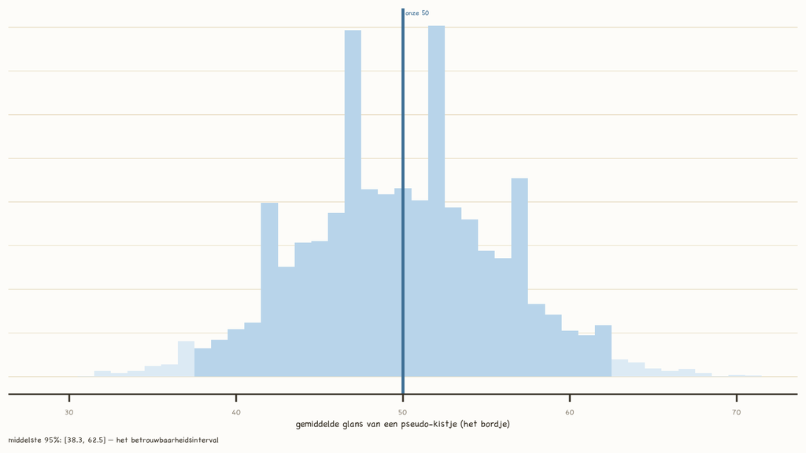

De middelste 95 van de echte bordjes lopen van **38.3 tot 62.5**. Bovengrens vrijwel wat je gokte, ondergrens een punt of wat af. Ongeveer raak — meer belooft een vuistregel niet.

Figuur v1 — de muur van gemiddelde-bordjes rond de 50. Interval = middelste 95% van de bordjes = **[38.3, 62.5]** (waarheidsscript): “ergens hier ligt het gemiddelde van de rivier, waarschijnlijk.”

GROF — de 95%-afspraak hier planten: Waarom de middelste 95? Afspraak. Net zo’n afspraak als de meter en de graad Celsius uit hoofdstuk 0 — we moesten iets kiezen, en de wetenschap koos vrijwel overal hetzelfde getal. Het keert zo terug in een andere jas.

En nu het getal waar het ons werkelijk om ging. Niks houdt ons tegen om op het bordje een ánder getal te schrijven. Trek opnieuw twaalf-met-teruglegging — en reken deze keer niet het gemiddelde maar **de $r$** van je pseudo-kistje uit. Zelfde spel, zelfde muur. Nieuw getal op het bordje.

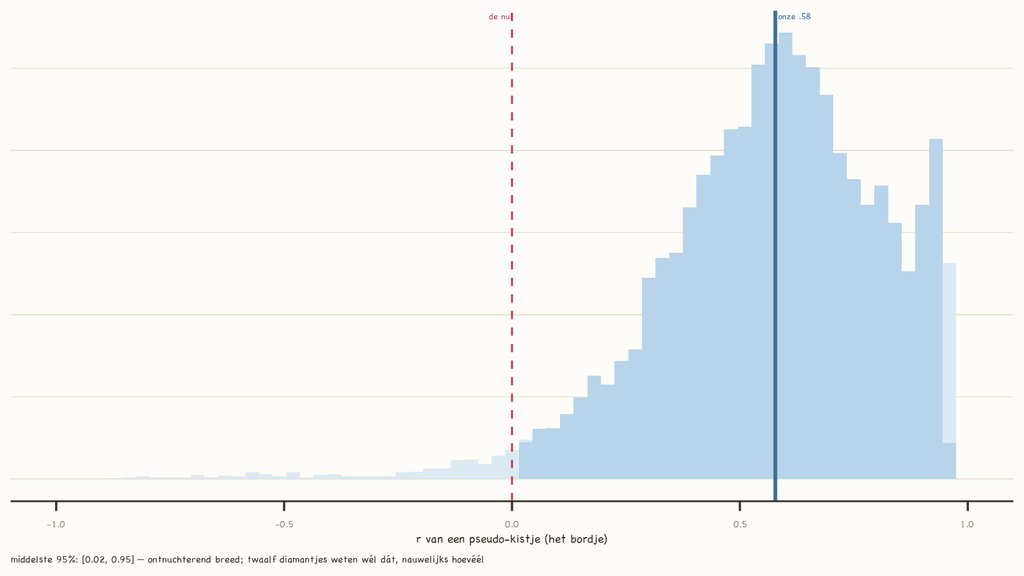

Figuur v1 — de muur van r-bordjes; onze .58 erin; middelste 95% = **[.02, .95]** (waarheidsscript). Ontnuchterend breed — en dát is de les: twaalf diamantjes weten wél dat er iets is, maar nauwelijks hoevéél. En kijk waar de linkergrens bijna komt: bij de nul. Die observatie gaat jeuken — sectie 3 krabt eraan. Eerlijkheid als deliverable. Eén regel voor het gemiddelde-toetsen-gat: een gemiddelde toetsen = een verband toetsen met nul voorspellers — dat ritueel oefen je in de werkboeken.

En dan is er nog een winkel om binnen te lopen. Bakker, akte 1 — de schatting: je loopt geblinddoekt een willekeurige winkel binnen en zegt: “doet u maar wat.” Je krijgt een brood in je handen. Welke winkel gok je? Een bakker, natuurlijk — beste gok. Maar zou je erop dúrven zweren? Brood krijg je ook bij een supermarkt, een tankstation, een schoolkantine. Je gok is goed, én hij heeft een marge — een rijtje winkels eromheen die óók hadden gekund. Precies zo staat het met onze .58.

## 3. De omkering — stel dat er niks is

Tot nu toe deden we wat we het hele boek al doen: we namen wat we hebben serieus, en vroegen hoe ver het wiebelt. **Onze eigen schatting stond in het midden.** Nu komt de raarste denkstap van dit boek — we nemen hem langzaam, want hij is werkelijk raar.

We zetten niet onze .58 in het midden, maar iets dat we zelf verzinnen: **de nul**. Stel — stel, stel, stel — dat er in de ton helemaal géén verband zit tussen karaat en glans. Niks. Nul. En vraag dan: *hoe gek is ons kistje in díé wereld?*

### De niks-wereld bouwen

Wat betekent “geen verband” concreet? Dat de glans van een diamant net zo goed bij een ándere diamant had kunnen horen. In die wereld zijn de paartjes — Anna’s 0.4 mét Anna’s 20, Kees’ 1.5 mét Kees’ 30 — puur toeval. Dus mogen we ze **losknippen en opnieuw uitdelen**.

Trede 1 — keukentafel, derde bezoek: schrijf de twaalf glans-waarden op twaalf kaartjes. Schud. Deel ze blind opnieuw uit aan de twaalf karaats — Anna krijgt zomaar een glans, Kees ook. Dit is de niks-wereld: alle karaats, alle glansjes, nul verband. Tel nu opnieuw de rechthoekjes-som van hoofdstuk 4. GROF: één keer voelen volstaat; meestal komt er iets kleins uit, ergens rond de nul — in de geschudde wereld heffen mee- en tegen-rechthoekjes elkaar op.

Eén keer schudden is een anekdote. Maar je weet inmiddels wat er komt als je niet stopt.

### De muur van geschudde werelden

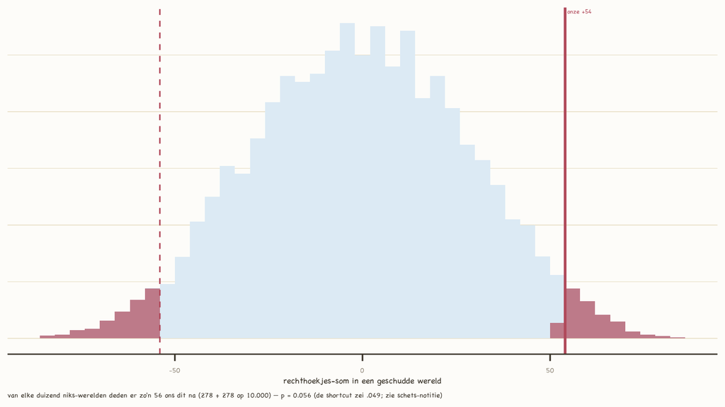

Figuur v1 (waarheidsscript: 278 + 278 op 10.000). Klontert rond 0, klokt — en daar, in de dunne staart, onze échte +54.

Duizend keer geschud, duizend niks-werelden, duizend sommen. Ze klonteren rond de nul en vormen — je had het kunnen voorspellen — een klok. En helemaal rechts, in de dunne staart, staat een streepje: **onze +54.**

### De bakker, akte twee

Terug naar de winkel. Daarnet vroegen we: *welke winkel past bij mijn brood?* — een schat-vraag, met een marge als antwoord. Nu draaien we ook hém om: **stel dat het een bakker ís.** Hoe gek is dan wat ik kreeg? Een brood: niks aan de hand. Een croissantje: prima. Maar een **fiets** — dan neem je de blinddoek af, want dit is geen bakkerij.

De vraag is dus: is +54 een brood of een fiets in de niks-wereld? Tel het maar getallen uit het waarheidsscript, seed 2026: van elke duizend geschudde werelden komen er zo’n **28** zo hoog als +54 — en nog eens **28** zo diep als −54, want extreem is extreem naar twee kanten Pippi: twee staarten, keer twee — kader. Samen: 56 op de 1000. Ruwweg één op de achttien.

Dat getal — het aandeel niks-werelden dat minstens zo extreem doet als jouw kistje — heet de **p-waarde**. Term-blokje: p-waarde, overschrijdingskans; als kans schrijven (.056), niet als percentage. Bij ons: $p$ = .056. Meer fiets dan brood, maar geen mammoet — en nét bóven de rand van wat onderzoekers, bij afspraak, “te raar voor toeval” noemen. Onthou dat getal even; er komt zo een ongemakkelijke verrassing. GROF: α = .05 als conventie — dezelfde familie van afspraken als de 95 van daarnet, één keer gekozen, overal gebruikt; geen natuurwet. De diamantjes zijn met opzet “net aan” ontworpen om de brosheid van die grens te laten voelen. Niet-triomfantelijke toon.

GROF — kader: **de omkeer-valkuil**, het diepste punt van dit hoofdstuk. Twee vragen die op elkaar lijken en het niet zijn: “hoe waarschijnlijk is brood, gegeven een bakker?” en “hoe waarschijnlijk is een bakker, gegeven brood?” De p-waarde beantwoordt uitsluitend de eerste. Wie p = .049 leest als “de kans dat er niks is, is .049” heeft de twee vragen verwisseld — en in akte 1 voelde je zelf al waarom dat niet mag: het brood maakte je niet zéker van de bakker. Uitwerken bij redactie-pas; geen Bayes-formules, alleen dit voelbaar houden.

## 4. De twee muren

Twee keer geschud, twee muren van uitkomsten. Ze lijken op elkaar, maar verwar ze nooit — één vraag houdt ze uit elkaar, voorgoed:

> *Wat staat er in het midden van de muur?*
- Bij het **interval** (de teruglegging): in het midden staat **onze eigen .58**. Wij namen ons kistje serieus en vroegen hoe ver het had kunnen wiebelen. Je begint bij je meting, je eindigt bij een marge.
- Bij de **toets** (de kaartjes): in het midden staat **nul** — de niks-wereld, die we zelf bouwden. Je begint bij een aanname (“stel…”), je eindigt bij een kans.

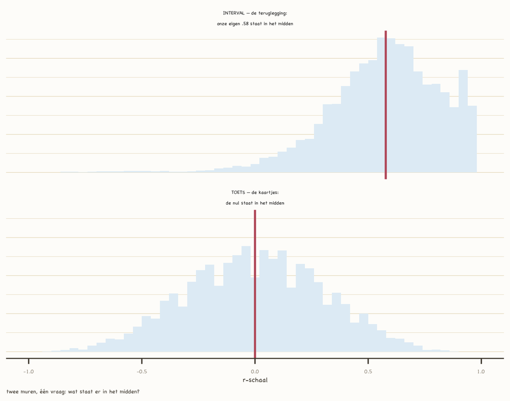

Figuur v1. Dit is het OZP-scharnier in simulatie-gedaante; het komt in de werkboeken terug als de x⇄z⇄p-richtingen. Hier alleen het gevoel, geen machinerie.

## 5. De shortcut — je hoeft niet altijd te schudden

GROF — de analytische brug, kort en ontspannen: Kijk nog één keer naar de muur van geschudde sommen. Een klok. Alwéér een klok — net als de bordjes-muur van hoofdstuk 3. Dat is geen toeval; het is dezelfde flauwe wet die daar al gold: schud vaak genoeg en de klok verschijnt, hoe lelijk de ingrediënten ook zijn.

En als je de vorm van de muur al ként voordat je geschud hebt, kun je het tellen overslaan. Wiskundigen hebben voor déze klok de maat genomen en er een verdeling met een naam aan gehangen — de *t-verdeling* — compleet met een recept dat rechtstreeks van jouw kistje naar de p springt, zonder één kaartje te schudden. En hier komt de verrassing die ik aankondigde: de formule zegt bij ons kistje **$p$ = .049**. Het schudden zei .056. Twee nette methodes, hetzelfde kistje — en ze landen aan weerszijden van de afspraakgrens: de formule zegt nét wel “te raar voor toeval”, het schudden zegt nét niet. GROF — dit is de eerlijkste les over α die er bestaat, en de diamantjes zijn er met opzet voor ontworpen: als één kistje bij twee eerlijke methodes aan twee kanten van de grens valt, dan is de grens een afspraak, geen meetinstrument. Niet oplossen, laten staan — de conclusie is niet “welke methode wint” maar “houd op met denken in wel/niet en kijk naar het interval van daarnet”. Toon: ontspannen, geen NHST-preek. Kanttekening voor onszelf: de .056 heeft Monte-Carlo-marge (±.005 bij B = 10.000) — vermelden hoeft niet, wel weten. Verder: alleen bestaan + gelijkenis van de shortcut tonen; het hand-ritueel (8 stappen, tabellen, kritieke waarden) is werkboek-stof, geen boek-stof.

Het schudden blijft de waarheid; de formule is de samenvatting ervan. Wie ooit vergeet wat een p-waarde is, hoeft alleen de kaartjes weer te pakken.

## 6. Werk

De hele bootstrap — het kistje duizend keer als ton behandelen — is ook één regel:

`replicate(1000, mean(sample(diamantjes$glans, replace = TRUE)))`

Duizend nieuwe pseudo-kistjes, elk gemiddelde op een bordje. Datzelfde spel op de r, en de permutatie (paartjes verbreken en tellen), doe je in het browser-speeltje; nul setup. En rekenen mét R met je eigen data — inclusief de shortcut-check met `cor.test()` — traint het R-oefenboek.

Sier-regel-besluit (7-7, keuzes §1): één regel R-om-te-lézen mag in dit simulatie-hoofdstuk blijven. Volledige kiem (bootstrap op gemiddelde én r, permutatie, shortcut-check, de leave-one-out-oefening): `03_oefenboek_kiemen/R_werk_uit_schetsen_2026-07-11.md`. De didactische leave-one-out-*demonstratie* (Kees/Else — twee polen) blijft in het boek als reken-beat; zie de open punten.

## 7. Sluiting

En daarmee is de tweede beweging rond. We kunnen verschillen koppelen én eerlijk zeggen hoe zeker we daarvan zijn. Wat we nog niet kunnen: begrijpen *waaróm* de grote meestal glanzen. Want er is iets dat we al die tijd niet gemeten hebben. De olifant heeft er al eens naar gekeken, naar die ene grote doffe — alsof er iets aan Kees te zien was dat niet in karaat en niet in glans zat.

Daarover gaat de derde beweging.

## Open punten (grof → redactie-pas)

- ✅ **OMBOUW DOORGEVOERD (besloten Ben 5-7 avond): interval vóór toets.** Rationale geborgd in keuzes.md: bootstrap = H3-spel op nieuw object (geen nieuwe denkstap); permutatie = conditioneel redeneren → als expliciete, langzame omkering ná het onvoorwaardelijke deel; gok-lijn H1→H3→H5a loopt door; schatten primair, toets als bijvraag (estimation-eerst, geen NHST-ritueel als climax); elf-scène vraagt naar wiebel; scharnier = de wending. Bakker in twee aktes + omkeer-valkuil-kader (P(brood|bakker) ≠ P(bakker|brood)); 95%-afspraak vóór α geplant (zelfde familie, “andere jas”).
- **Werktitel heroverwegen**: *Bestaat het echt?* legt het accent op de toets, terwijl het hoofdstuk nu schat-eerst is. Kandidaten: *Hoe hard is meestal?* / *De wiebel en de fiets* / titel houden (de vraag blijft de spannendste). Bens call.
- ✅ **Getallen vastgesteld** — `_waarheid_getallen.R` (seed 2026, B = 10.000; output in `_waarheid_getallen_OUTPUT.txt`): bootstrap-95% gemiddelde [38.3, 62.5] · r [.02, .95] · b [1.0, 66.2]; permutatie tweezijdig p = .056 (28+28 per 1000) — **aan de andere kant van de grens dan de shortcut (.049): bewust uitgespeeld in §5**; leave-one-out zie kraai-vondst hieronder.
- **Figuren:** bootstrap-muur mét middelste-95%; muur-van-geschudde-sommen mét +54-streepje; twee-muren-minifiguur (“wat staat er in het midden?”). Zelfde hand-stijl als H3-panelen.
- **Kaartjes-schudding keukentafel**: twaalf producten optellen is fors — evt. mini-voorbeeld (n = 5?) voor de hand-ronde, diamantjes voor de muur.
- **t-dosering** (raakt H3-besluit “z-dosering”): neiging — alleen bestaan
  - gelijkheid van de shortcut; ritueel is werkboek-stof. Bevestigen.
- **Pippi/tweezijdig**: kader (twee staarten, keer twee) — consistent met OZP-conventie (Pippi = p ×2; kritieke-waarde-route hoort bij werkboeken).
- ✅ **Gemiddelde-inferentie — BESLOTEN (Ben 5-7, avond):** het *interval* start wél op het gemiddelde (opstap in §2: bootstrap eerst op de gemiddelde glans, dan r — zelfde muur, nieuw getal op het bordje); de *toets* op één gemiddelde komt níét in het boek — geen natuurlijke μ₀ in het verhaal, permutatie bestaat alleen voor relaties, en een éénsteekproefs-toets zou de analytische machinerie vervroegen. Eén regel volstaat: gemiddelde toetsen = verband toetsen met nul voorspellers → werkboeken. Geborgd in keuzes.md.
- **Kraai-vondst (waarheidsscript, leave-one-out): had de kraai Kees gepakt, dan was r = .79 en p = .004 geweest — geen twijfel meer.** Range zonder-één-diamant: [.47, .79]. Didactisch goud: één dief kan een twijfelgeval in een hard verband veranderen (of andersom). → **SLOT-VERDELING BESLOTEN (Ben 11-7, optie A): één demonstratie met twee polen in de §6-omgeving** — Kees eruit: álles verandert (r → .79), en dít is de Wilde-alinea (de betrapte gedachte “één dief verwijderd van zekerheid”); Else eruit: er beweegt geen haar (r en b exact gelijk, want ze ligt op beide gemiddelden), alleen p wipt .049 → .063. Twee polen, één beat met een donkere helft — géén drie losse coda’s. **§7 blijft kaal** (olifant-afronding + kunnen-balans + Kees/H6-teaser). De “wie pakte de kraai”-quiz (#6) komt er NIET (gekilld: stapelt op dezelfde diefstal + toon-botst met de elf-scène); de doffe-kwart-som gaat als reken-beat naar het oefenboek. Regie-regel: de stem-pas mag dit slot niet openbreken.
- **Verhaal-slot**: de “iets aan Kees”-zin is de gladheid-teaser (H6) — checken of hij niet te veel verklapt.
- **Bib-borging**: elf-scène, “hoeveel kraaien verdraagt een patroon”, kistje-als-ton, bakker-twee-aktes, omkeer-valkuil → molen-ronde.
- ✅ **Werk-sectie → tabs (besloten 6-7), hier R vooraan:** bootstrap- en permutatie-spel ís het verhaal; JASP-tab eerlijk over wat daar wel/niet kan. Zie keuzes.md §1.

Een boek in wording je leest mee terwijl het zijn vorm vindt